# Practical Machine Learning Project

Rafael Cobo

17 Mar 2015

### BACKGROUND

Using devices such as Jawbone Up, Nike FuelBand, and Fitbit it is now possible to collect a large amount of data about personal activity relatively inexpensively. These type of devices are part of the quantified self movement ??? a group of enthusiasts who take measurements about themselves regularly to improve their health, to find patterns in their behavior, or because they are tech geeks. One thing that people regularly do is quantify how much of a particular activity they do, but they rarely quantify how well they do it. In this project, your goal will be to use data from accelerometers on the belt, forearm, arm, and dumbell of 6 participants. They were asked to perform barbell lifts correctly and incorrectly in 5 different ways. More information is available from the website here: http://groupware.les.inf.puc-rio.br/har (see the section on the Weight Lifting Exercise Dataset).

### SPECIFICATIONS

- MacBook (2008)
- Processor 2 GHz Intel Core 2 Duo (2GB)
- OS X Yosemite Version 10.10
- RStudio Version 0.98.1091
- R Version 3.1.2 (2014-10-31)

```r
library(caret)
library(rpart)
library(e1071)
library(randomForest)
library(ggplot2)
library(reshape2)
library(gridExtra)
```

In this project, your goal will be to use data from accelerometers on the belt, forearm, arm, and dumbell of 6 participants. They were asked to perform barbell lifts correctly and incorrectly in 5 different ways. More information is available from the website here: http://groupware.les.inf.puc-rio.br/har (see the section on the Weight Lifting Exercise Dataset).

### PART I.- LOADING AND PREPARING DATA

The training data for this project are available here:

```r
rawtrain <- read.csv("http://d396qusza40orc.cloudfront.net/predmachlearn/pml-training.csv")
dim(rawtrain)
```

```
## [1] 19622   160
```

The test data are available here:

```r
rawtest <- read.csv("http://d396qusza40orc.cloudfront.net/predmachlearn/pml-testing.csv")
dim(rawtest)
```

```
## [1]  20 160
```

We will only use 52 predictors (13 for each group: belt, arm, dumbbell and forearm) and the outcome classe. We’ll drop the rest of variables

```r
btrain <- rawtrain[, which(sapply(rawtest, function(x)all(is.na(x))) == FALSE)]
trainf <- btrain[, 8:60]
colnames(trainf)
```

```
##  [1] "roll_belt"            "pitch_belt"           "yaw_belt"
##  [4] "total_accel_belt"     "gyros_belt_x"         "gyros_belt_y"
##  [7] "gyros_belt_z"         "accel_belt_x"         "accel_belt_y"
## [10] "accel_belt_z"         "magnet_belt_x"        "magnet_belt_y"
## [13] "magnet_belt_z"        "roll_arm"             "pitch_arm"
## [16] "yaw_arm"              "total_accel_arm"      "gyros_arm_x"
## [19] "gyros_arm_y"          "gyros_arm_z"          "accel_arm_x"
## [22] "accel_arm_y"          "accel_arm_z"          "magnet_arm_x"
## [25] "magnet_arm_y"         "magnet_arm_z"         "roll_dumbbell"
## [28] "pitch_dumbbell"       "yaw_dumbbell"         "total_accel_dumbbell"
## [31] "gyros_dumbbell_x"     "gyros_dumbbell_y"     "gyros_dumbbell_z"
## [34] "accel_dumbbell_x"     "accel_dumbbell_y"     "accel_dumbbell_z"
## [37] "magnet_dumbbell_x"    "magnet_dumbbell_y"    "magnet_dumbbell_z"
## [40] "roll_forearm"         "pitch_forearm"        "yaw_forearm"
## [43] "total_accel_forearm"  "gyros_forearm_x"      "gyros_forearm_y"
## [46] "gyros_forearm_z"      "accel_forearm_x"      "accel_forearm_y"
## [49] "accel_forearm_z"      "magnet_forearm_x"     "magnet_forearm_y"
## [52] "magnet_forearm_z"     "classe"
```

```r
set.seed(8128) # Reproducibility
inTrain <- createDataPartition(trainf$classe, p = 0.7, list = FALSE)
train <- trainf[inTrain, ]
probe <- trainf[-inTrain, ]
dim(train)
```

```
## [1] 13737    53
```

```r
dim(probe)
```

```
## [1] 5885   53
```

We havent missing values or NAs in our trainf

### PART II.- EXPLORATORY DATA ANALYSIS

Note that outcome variable is not equally distributed between the clases.

```
##              A         B         C         D         E
## [1,] 3906.0000 2658.0000 2396.0000 2252.0000 2525.0000
## [2,]    0.2843    0.1935    0.1744    0.1639    0.1838
```

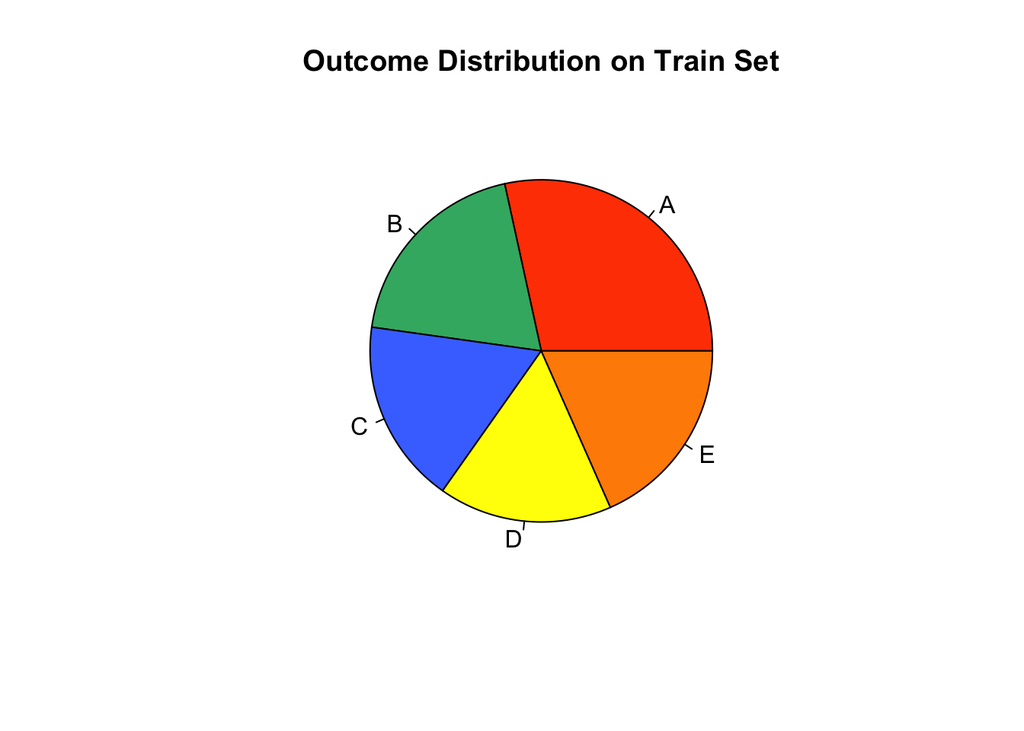

We can take a look into the predictors. Some examples:

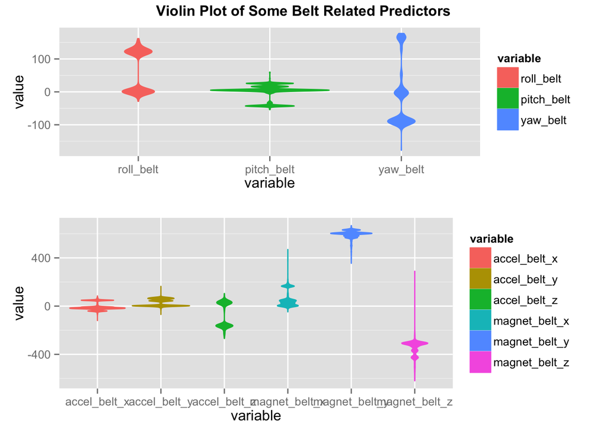

### PART III.- RANDOM FOREST ALL PREDICTORS

Why Random Forest? The method perform an OOB error analysis and estimation The method provides a ranking for the predictors We avoid preprocessing the predictors data It is appropiate to deal with a large number of predictors (52 in our case)

```r
rf_all <- randomForest(classe ~ ., data = train, importance = TRUE)
rf_all
```

```
##
## Call:
##  randomForest(formula = classe ~ ., data = train, importance = TRUE)
##                Type of random forest: classification
##                      Number of trees: 500
## No. of variables tried at each split: 7
##
##         OOB estimate of  error rate: 0.52%
## Confusion matrix:
##      A    B    C    D    E class.error
## A 3905    1    0    0    0    0.000256
## B   14 2637    7    0    0    0.007901
## C    0   15 2378    3    0    0.007513
## D    0    0   23 2227    2    0.011101
## E    0    0    1    5 2519    0.002376
```

Amazing OOB estimate of error. Now let’s see the confusion matrix on probe data that previously we had set aside:

```r
confusionMatrix(predict(rf_all, probe), probe$classe)
```

```
## Confusion Matrix and Statistics
##
##           Reference
## Prediction    A    B    C    D    E
##          A 1672    4    0    0    0
##          B    2 1133    4    0    0
##          C    0    2 1022    2    0
##          D    0    0    0  961    2
##          E    0    0    0    1 1080
##
## Overall Statistics
##
##                Accuracy : 0.997
##                  95% CI : (0.995, 0.998)
##     No Information Rate : 0.284
##     P-Value [Acc > NIR] : <2e-16
##
##                   Kappa : 0.996
##  Mcnemar's Test P-Value : NA
##
## Statistics by Class:
##
##                      Class: A Class: B Class: C Class: D Class: E
## Sensitivity             0.999    0.995    0.996    0.997    0.998
## Specificity             0.999    0.999    0.999    1.000    1.000
## Pos Pred Value          0.998    0.995    0.996    0.998    0.999
## Neg Pred Value          1.000    0.999    0.999    0.999    1.000
## Prevalence              0.284    0.194    0.174    0.164    0.184
## Detection Rate          0.284    0.193    0.174    0.163    0.184
## Detection Prevalence    0.285    0.194    0.174    0.164    0.184
## Balanced Accuracy       0.999    0.997    0.998    0.998    0.999
```

It’s promising that the accuracy remains so high. Now we’ll look at the variable importance plot. Top 20:

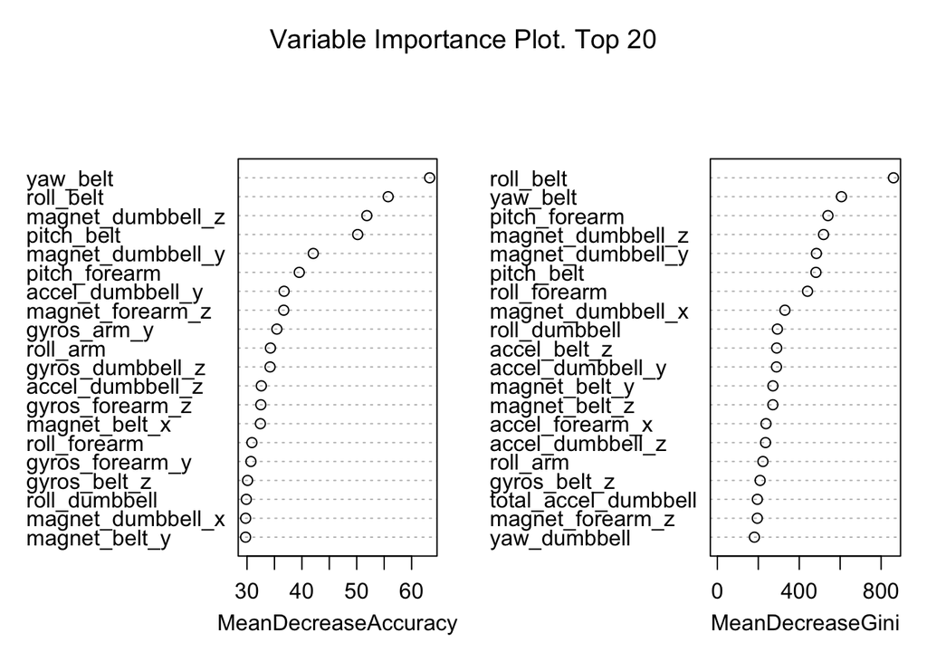

```r
varImpPlot(rf_all, sort = TRUE, n.var = 20, main = "Variable Importance Plot. Top 20")
```

### PART IV.- RANDOM FOREST SOME PREDICTORS

```r
rf_some <- randomForest(classe ~ yaw_belt + roll_belt + pitch_belt + magnet_dumbbell_z + magnet_dumbbell_y + pitch_forearm + gyros_arm_y + gyros_dumbbell_z + accel_dumbbell_y + magnet_belt_x, data = train, importance = FALSE)
rf_some
```

```
##
## Call:
##  randomForest(formula = classe ~ yaw_belt + roll_belt + pitch_belt +      magnet_dumbbell_z + magnet_dumbbell_y + pitch_forearm + gyros_arm_y +      gyros_dumbbell_z + accel_dumbbell_y + magnet_belt_x, data = train,      importance = FALSE)
##                Type of random forest: classification
##                      Number of trees: 500
## No. of variables tried at each split: 3
##
##         OOB estimate of  error rate: 1.55%
## Confusion matrix:
##      A    B    C    D    E class.error
## A 3875   14   10    7    0    0.007937
## B   37 2587   31    2    1    0.026712
## C    4   17 2356   17    2    0.016694
## D    4    0   39 2207    2    0.019982
## E    0   11   10    5 2499    0.010297
```

Using only ten predictors we also have a very good OOB estimate of error. Again let’s see the confusion matrix on probe data for the 10 predictors random forest

```
## Confusion Matrix and Statistics
##
##           Reference
## Prediction    A    B    C    D    E
##          A 1661   17    3    3    0
##          B    5 1089    8    1    4
##          C    4   25 1007   10    3
##          D    3    8    8  948    2
##          E    1    0    0    2 1073
##
## Overall Statistics
##
##                Accuracy : 0.982
##                  95% CI : (0.978, 0.985)
##     No Information Rate : 0.284
##     P-Value [Acc > NIR] : < 2e-16
##
##                   Kappa : 0.977
##  Mcnemar's Test P-Value : 0.00119
##
## Statistics by Class:
##
##                      Class: A Class: B Class: C Class: D Class: E
## Sensitivity             0.992    0.956    0.981    0.983    0.992
## Specificity             0.995    0.996    0.991    0.996    0.999
## Pos Pred Value          0.986    0.984    0.960    0.978    0.997
## Neg Pred Value          0.997    0.990    0.996    0.997    0.998
## Prevalence              0.284    0.194    0.174    0.164    0.184
## Detection Rate          0.282    0.185    0.171    0.161    0.182
## Detection Prevalence    0.286    0.188    0.178    0.165    0.183
## Balanced Accuracy       0.993    0.976    0.986    0.990    0.996
```

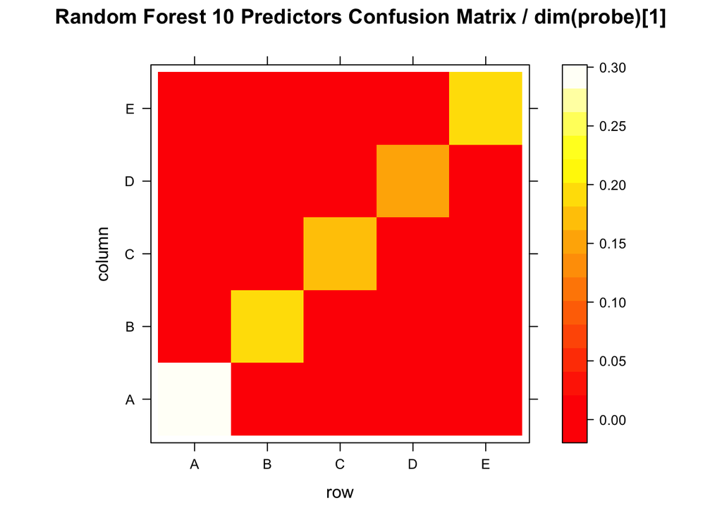

### PART V.- FORECASTING

```r
forecast_all <- predict(rf_all, rawtest)
forecast_all
```

```
##  1  2  3  4  5  6  7  8  9 10 11 12 13 14 15 16 17 18 19 20
##  B  A  B  A  A  E  D  B  A  A  B  C  B  A  E  E  A  B  B  B
## Levels: A B C D E
```

```r
forecast_some <- predict(rf_some, rawtest)
forecast_some
```

```
##  1  2  3  4  5  6  7  8  9 10 11 12 13 14 15 16 17 18 19 20
##  B  A  B  A  A  E  D  B  A  A  B  C  B  A  E  E  A  B  B  B
## Levels: A B C D E
```